# Tarea - 2

Román Alberto Vélez Jiménez

```r
library(tidyverse)
```

# Series de tiempo

Consideramos la ventas semanales de un producto a lo largo de 5 años, transformaremos la variable de ventas utilizando el logaritmo.

1. Describe que observas en la gráfica.

```r
ventas <- read_csv("../data/ventas_semanal.csv")
head(ventas)
```

```
## # A tibble: 6 × 2
##   period sales.kg
##    <dbl>    <dbl>
## 1      1     686.
## 2      2     768.
## 3      3     895.
## 4      4     774.
## 5      5     955.
## 6      6     853.
```

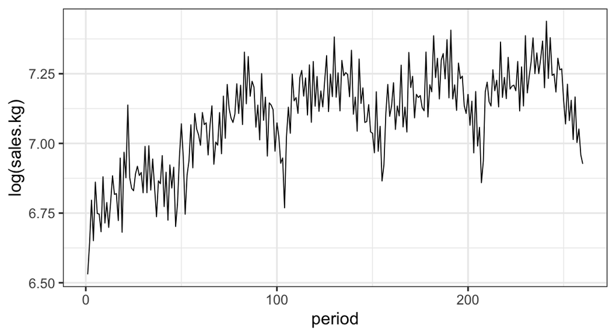

```r
ggplot(ventas, aes(x = period, y = log(sales.kg))) +
  geom_line(size = 0.3) +
  theme_bw()
```

## Observations

1. It looks there is a multiplicative effect
2. There is an upper tendency
3. Stationality quiet clear
4. The time series maybe has cycles every 50 periods

# Q2: Utiliza un suavizador *loess* para capturar la tendencia de la serie.

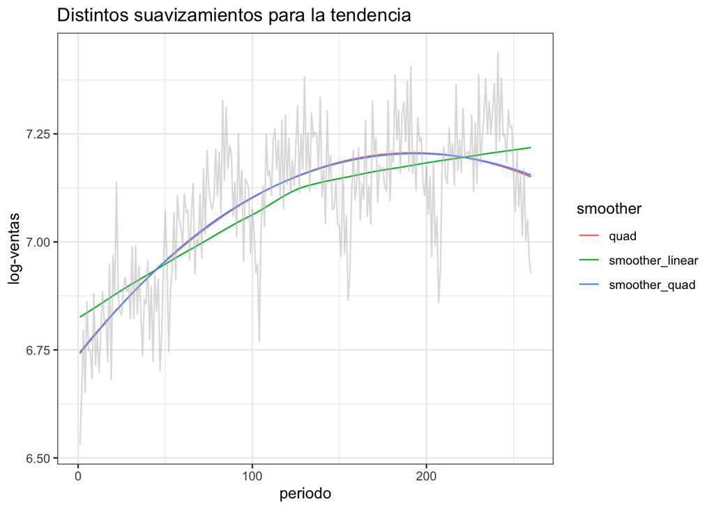

```r
# get 4 types ofadjustmen
ventas <- ventas |>
  mutate(
    trend_1_smoother_linear = fitted(loess(log(sales.kg) ~ period, ventas, span = 1, degree = 1)),
    trend_1_quad = fitted(loess(log(sales.kg) ~ period, ventas, span = 3, degree = 2)),
    trend_1_smoother_quad = fitted(loess(log(sales.kg) ~ period, ventas, span = 2, degree = 2)),
  )

# plot adjustment
ventas |>
  pivot_longer(
    cols = starts_with("trend_1"),
    names_to = "smoother",
    values_to = "res1"
  ) |>
  mutate(
    smoother = str_remove(smoother, "trend_1_")
  ) |>
  ggplot(aes(period, res1, color = smoother)) +
  geom_line() +
  geom_line(
    data = ventas,
    aes(period, log(sales.kg)),
    color = "gray",
    alpha = 0.5
  ) +
  xlab("periodo") + ylab("log-ventas") +
  ggtitle("Distintos suavizamientos para la tendencia") +
  theme_bw()
```

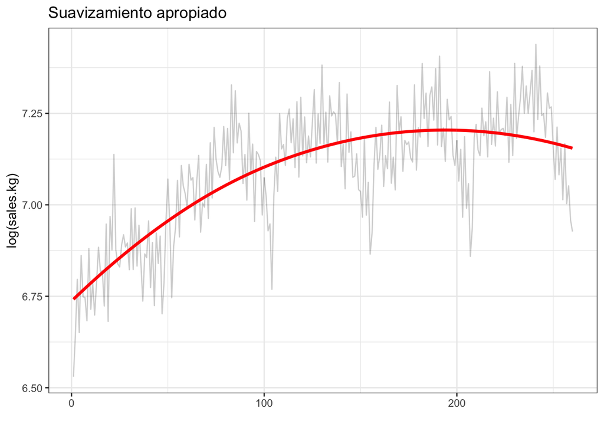

```r
# plot
ggplot(ventas, aes(period, log(sales.kg))) +
  geom_line(alpha = 0.2) +
  geom_line(aes(y = trend_1_smoother_quad), colour = "red", size = 1.2) + xlab("") +
  ggtitle("Suavizamiento apropiado") +
  theme_bw()
```

# Q3: Residuals

3. Ahora calcula los residuales de este ajuste y descríbelos mediante un suavizamiento más fino. Verifica que se ha estimado la mayor parte de la tendencia, e intenta capturar la variación estacional de los residuales.

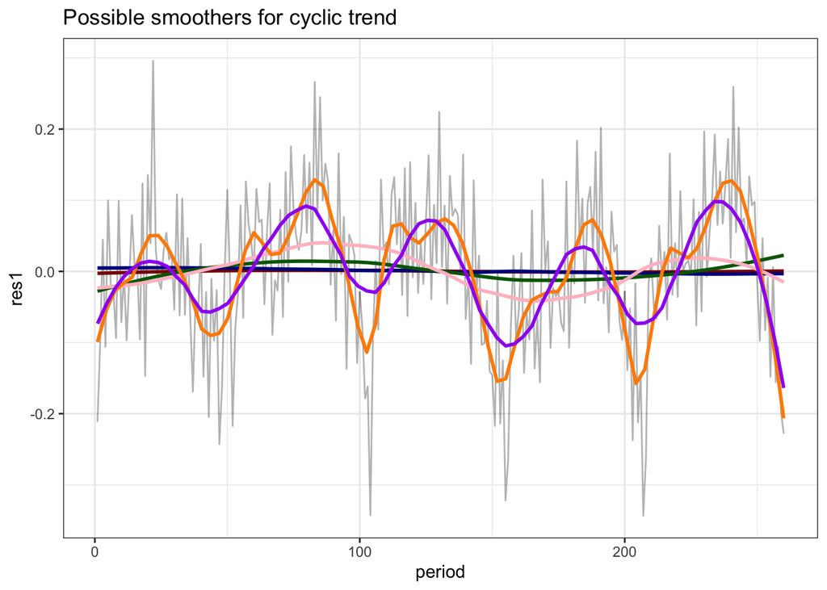

```r
# get residuals
ventas <- ventas |>
  mutate(
    res1 = log(sales.kg) - trend_1_smoother_quad
  )

# look for residuals
ventas |>
  ggplot(aes(period, res1)) +
  geom_line(aes(y = res1), alpha = 0.3) +
  geom_smooth(color = 'darkred', method = loess, method.args = list(degree = 2, span = 3), se = FALSE) +
  geom_smooth(color = 'darkblue', method = loess, method.args = list(degree = 1, span = 1), se = FALSE) +
  geom_smooth(color = 'darkgreen', method = loess, method.args = list(degree = 2, span = 1), se = FALSE) +
  geom_smooth(color = 'pink', method = loess, method.args = list(degree = 2, span = 0.5), se = FALSE) +
  geom_smooth(color = 'darkorange', method = loess, method.args = list(degree = 2, span = 0.1), se = FALSE) +
  geom_smooth(color = 'purple', method = loess, method.args = list(degree = 2, span = 0.25), se = FALSE) +
  ggtitle("Possible smoothers for cyclic trend") +
  theme_bw()
```

Doing a lot of possible smoothers, it looks that a loess with $\lambda = 0.1$ and $\partial(p) = 2$ captures best the cyclic tendency.

# Q4: Residuals and frequency

4. Grafica los residuales obtenidos después de ajustar el componente estacional para estudiar la componente de mayor frecuencia.

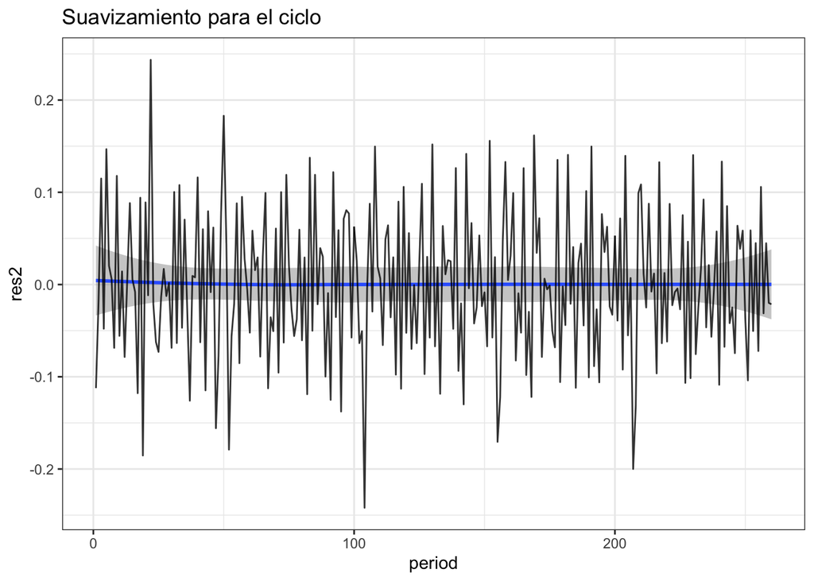

```r
# plt
ventas <- ventas |>
  mutate(
    trend2 = fitted(loess(res1 ~ period, span = 0.1, degree = 2)),
    res2 = res1 - trend2
  )

ggplot(ventas, aes(period, res2)) +
  geom_smooth(alpha = 0.5) +
  geom_line(alpha = 0.8) +
  ggtitle("Suavizamiento para el ciclo") +
  theme_bw()
```

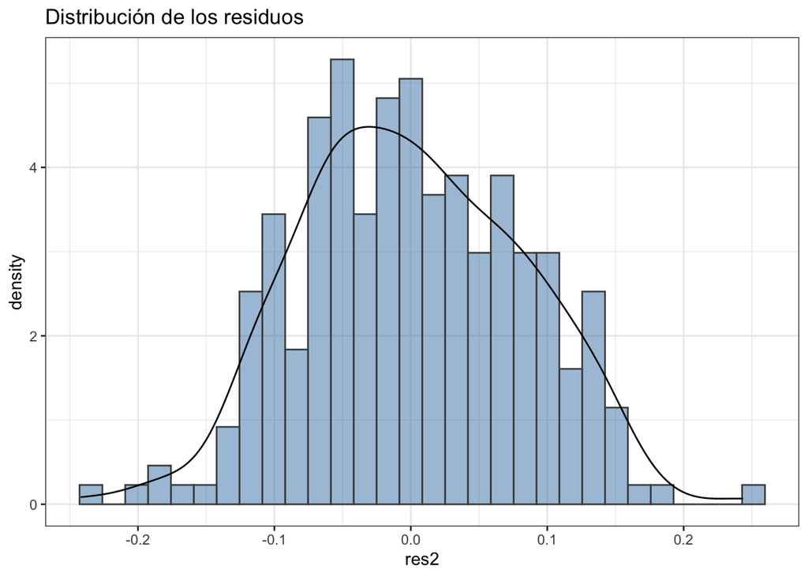

```r
# describe errors (look if they look sort of "normal")
ventas |>
  ggplot(aes(res2)) +
  geom_histogram(aes(y = after_stat(density)), fill = "steelblue", color = "gray30", alpha = 0.5) +
  geom_density() +
  ggtitle("Distribución de los residuos") +
  theme_bw()
```

It looks that we have already took all the cyclical part.

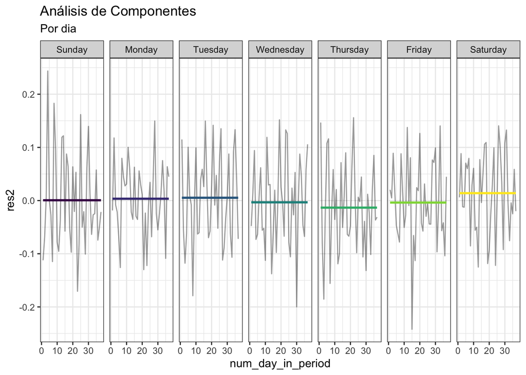

```r
# generate days of the week
DAY_MAP <- c("Sunday", "Monday", "Tuesday", "Wednesday", "Thursday", "Friday", "Saturday")
ventas <- ventas |>
  mutate(
    # generate fictional data
    weekday = DAY_MAP[((period-1) %% 7) + 1],
    weekday = factor(weekday, levels = DAY_MAP)
  ) |>
  group_by(weekday) |>
  mutate(num_day_in_period = row_number()) |>
  ungroup()

# get component info (separated)
ventas |>
  ggplot(aes(num_day_in_period, res2)) +
  geom_line(alpha = 0.4) +
  geom_smooth(aes(color = weekday), method = "lm", formula = "y ~ 1", se = FALSE) +
  facet_grid(~ weekday) +
  ggtitle("Análisis de Componentes", "Por dia") +
  scale_color_viridis_d() +
  theme_bw() +
  theme(
    legend.position = "None"
  )
```

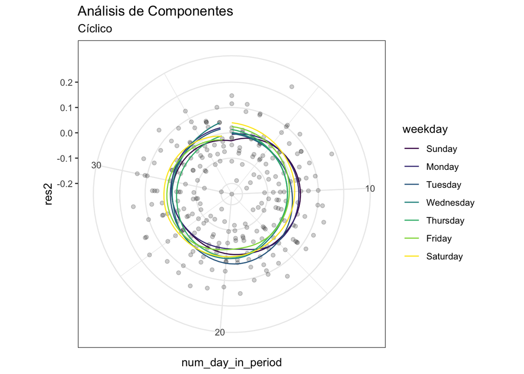

```r
# get component info (separated & polar)
ventas |>
  ggplot(aes(num_day_in_period, res2)) +
  geom_point(alpha = 0.2) +
  geom_smooth(aes(color = weekday), se = FALSE, size = 0.5) +
  coord_polar() +
  scale_color_viridis_d() +
  ggtitle("Análisis de Componentes", "Cíclico") +
  theme_bw()
```

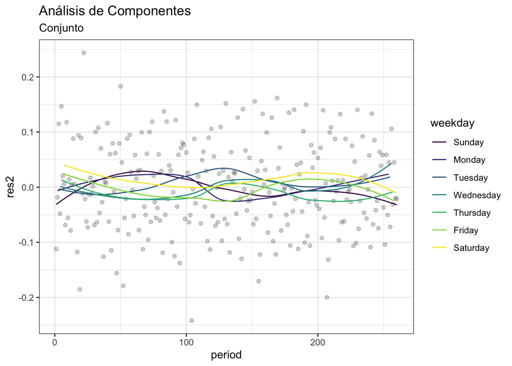

```r
# get component info (join)
ventas |>
  ggplot(aes(period, res2)) +
  geom_point(alpha = 0.2) +
  geom_smooth(aes(color = weekday), se = FALSE, size = 0.5) +
  ggtitle("Análisis de Componentes", "Conjunto") +
  scale_color_viridis_d() +
  theme_bw()
```

Given the graphs, it does not looks that the day of the week creates a difference, nor there is a more important component than other. But for the exercise we will still adjust it.

# Q5: Optional.

5. (opcional) Visualiza el ajuste, genera una gráfica de páneles, en cada uno muestra una componente de la serie de tiempo y los residuales.

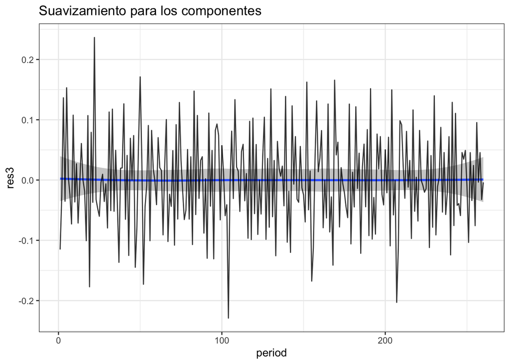

```r
# get components loess
df_components <- ventas |>
  group_by(weekday) |>
  nest() |>
  mutate(
    trend3 = map(data, ~ loess(res2 ~ period, data = .x, span = 0.75, degree = 1)),
    trend3 = map(trend3, fitted)
  ) |>
  unnest(cols = c(data, trend3)) |>
  mutate(res3 = res2 - trend3) |>
  ungroup()

# plot resiudals
ggplot(df_components, aes(period, res3)) +
  geom_smooth(alpha = 0.5) +
  geom_line(alpha = 0.8) +
  ggtitle("Suavizamiento para los componentes") +
  theme_bw()
```

```r
df_panels <- df_components |>
  mutate(
    trend1_centered = trend_1_smoother_quad - mean(trend_1_smoother_quad)
  ) |>
  rename(
    trend1 = trend1_centered
  ) |>
  select(
    period, weekday, sales.kg, trend1, trend2, trend3, res3
  ) |>
  pivot_longer(
    cols = c(starts_with("trend"), res3),
    names_to = "component",
    values_to = "value"
  ) |>
  mutate(
    component = recode(component,
                       trend1 = "trend",
                       trend2 = "stationality",
                       trend3 = "weekdays",
                       res3 = "residuals"
                       ),
    component = factor(component,
                       levels = c("trend", "stationality", "weekdays", "residuals")
                       )
  )
df_panels
```

```
## # A tibble: 1,040 × 5
##    period weekday sales.kg component       value
##     <dbl> <fct>      <dbl> <fct>           <dbl>
##  1      1 Sunday      686. trend        -0.347
##  2      1 Sunday      686. stationality -0.0992
##  3      1 Sunday      686. weekdays      0.00291
##  4      1 Sunday      686. residuals    -0.115
##  5      8 Sunday      799. trend        -0.312
##  6      8 Sunday      799. stationality -0.0247
##  7      8 Sunday      799. weekdays      0.00422
##  8      8 Sunday      799. residuals    -0.0729
##  9     15 Sunday      913. trend        -0.279
## 10     15 Sunday      913. stationality  0.00186
## # … with 1,030 more rows
```

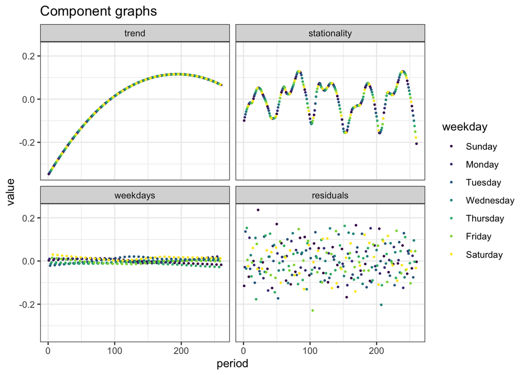

```r
df_panels |>
  ggplot(aes(period, value, color = weekday)) +
  geom_point(size = 0.5) +
  facet_wrap(~ component) +
  scale_color_viridis_d() +
  ggtitle("Component graphs") +
  theme_bw()
```